# Comparing Models On Surival Trends For Skin Cancer

## Project Motivation:

The goal of this project is to compare a few different multivariable models on how well they predict survival rates for skin cancer. NHS and other health data are often difficult to model accurately due to many factors contributing to the results, as well as some randomness that can’t necessarily be predicted. We were interested in seeing how a few models stand up when dealing with such data sets.

We will be looking at three factors towards predicting the survival rate - gender, ethnicity and level of deprivation. The survival rate is based on the Kaplain-meier 36 month survival rate, and we took the average for each datapoint. Gender was a binary factor taking Female or other for simplicity. Ethnicity was used as a proportion of white to non-white - a factor than could have some determination to the survival outcome. The level of deprivation was taken on an average scale of most deprived to least deprived (1-5).

After creating each model using the same three variables for prediction, we should have a fair test to see which model is the most effective.

## Data:

We took our data from an open source data set on cancer published by the nhs containing data from 2013 to 2022, which can be found here: “https://digital.nhs.uk/ndrs/data/data-outputs/cancer-data-hub/get-data-out”. This data set contained information on all types of cancer recorded in groups.

The columns used in our analysis were: 1,2,3,15,17,18,21,69,70,71,72,73,74,75,76,77,78,79,80,106,198, which includes to KM 36 months survival, ethnicities, gender and deprivation. We also filtered by rows to only select the skin cancer cases, by filtering through column 1 and 2.

TO pre-process our data before use, we had to change the ethnicities to a proportion, this involved filtering out some rows where most participants had unknown ethnicity, as the data here would not have been complete. Additionally, since the data was stored in a wide format, we then took total white ethnicity divided by total participants in each row to create a new column for proportion of white ethnicity. For the deprivation, we had to make a similar change where we ran the set of five columns for each ethnicity group into a function that gave the average ethnicity as a range from 1 to 5. We also converted the gender into a factor and converted the survival rate to numeric.

The libraries used in R-studio were: tidyverse (for data cleaning), ggplot2 (for graphing and modelling), mgcv (for modelling) and randomForest (for modelling).

## Methods:

We used the following modelling methods for our comparison: Linear regression model, generalised additive model (GAM), and random forest model. The linear regression model provides a good baseline and allows us to test the data for linear trends. The GAM then expands on this by allowing for non-linearity in the relationships, which could give a better prediction if the effect is non-linear. Then the random forest model takes a machine learning approach by combining the outputs of an array of decision trees to find a potentially complex relationship between the variables and outcome.

## Results:

```r
summary(lm_model)
```

```
##
## Call:
## lm(formula = KM36 ~ Dep_Avg + Gender + PropWhite, data = dataset)
##
## Residuals:
##     Min      1Q  Median      3Q     Max
## -51.244 -10.542   5.455   9.922  17.240
##
## Coefficients:
##              Estimate Std. Error t value Pr(>|t|)
## (Intercept)  108.9100    13.5301   8.049 1.07e-15 ***
## Dep_Avg        5.5125     0.6873   8.021 1.34e-15 ***
## GenderFemale   2.9725     0.3913   7.596 3.73e-14 ***
## PropWhite    -42.7368    13.8421  -3.087  0.00203 **
## ---
## Signif. codes:  0 '***' 0.001 '**' 0.01 '*' 0.05 '.' 0.1 ' ' 1
##
## Residual standard error: 12.73 on 4251 degrees of freedom
##   (5593 observations deleted due to missingness)
## Multiple R-squared:  0.02674,    Adjusted R-squared:  0.02606
## F-statistic: 38.94 on 3 and 4251 DF,  p-value: < 2.2e-16
```

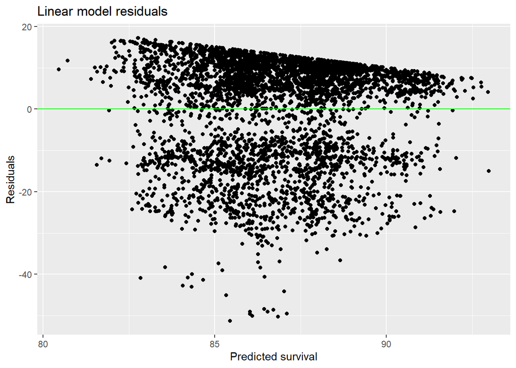

```r
print(plot_1)
```

```r
summary(gam_model)
```

```
##
## Family: gaussian
## Link function: identity
##
## Formula:
## KM36 ~ s(Dep_Avg) + Gender + PropWhite
##
## Parametric coefficients:
##              Estimate Std. Error t value Pr(>|t|)
## (Intercept)  134.7487    14.0071   9.620  < 2e-16 ***
## GenderFemale   3.0637     0.3916   7.823 6.48e-15 ***
## PropWhite    -49.9732    14.1580  -3.530  0.00042 ***
## ---
## Signif. codes:  0 '***' 0.001 '**' 0.01 '*' 0.05 '.' 0.1 ' ' 1
##
## Approximate significance of smooth terms:
##              edf Ref.df     F p-value
## s(Dep_Avg) 8.846  8.993 10.81  <2e-16 ***
## ---
## Signif. codes:  0 '***' 0.001 '**' 0.01 '*' 0.05 '.' 0.1 ' ' 1
##
## R-sq.(adj) =  0.0318   Deviance explained = 3.42%
## GCV = 161.47  Scale est. = 161.02    n = 4255
```

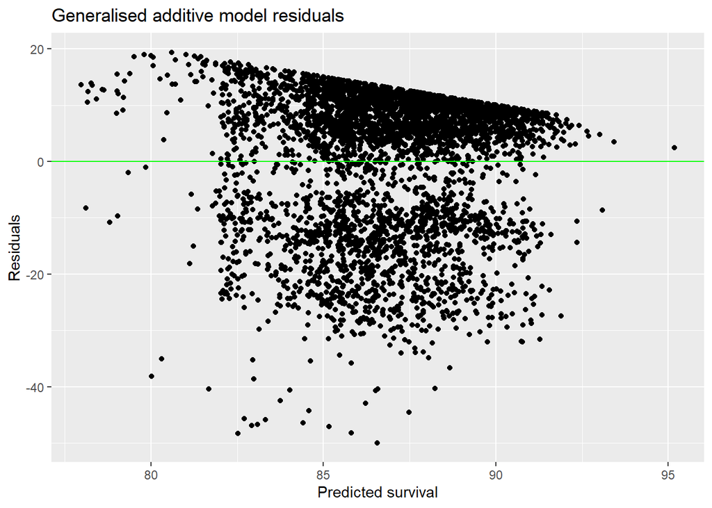

```r
print(plot_2)
```

```r
print(RF_model)
```

```
##
## Call:
##  randomForest(formula = KM36 ~ Dep_Avg + Gender + PropWhite, data = dataset_rf,      ntree = 1000, mtry = 2, importance = TRUE)
##                Type of random forest: regression
##                      Number of trees: 1000
## No. of variables tried at each split: 2
##
##           Mean of squared residuals: 161.5377
##                     % Var explained: 2.84
```

[figure not shown]

```r
print(plot_3)
```

## Discussion:

After reviewing our models, we got an expected level of variance explained by each model given the complexity of dealing with health data.

The linear regression model gave us an R-squared value of 0.026 which suggests only about 2.6% of variation is explained by the model, which we can expect to be low. The model therefore did capture some trend between the variables but assumpions based off this trend are limited and not reliable.

The GAM gave us an R-squared value of 0.032 which suggests that more variation was explained compared to the linear model, but only by a small margin. This could indicate that the GAM found a non-linear relationship that was better than just using the linear relationship in our prediction. Once again, using this model for predictions would be limited but it does help to show some correlations.

Finally, the random forest explained around 2.8% of variance. Despite not increasing the prediction value compared to the other models, there is still value in exploring the importance of each variable to better refine future models. However, in order for the model to work, NAs needed to be removed from the data causing a loss of roughly 50% of the rows.

## Conclusion:

In future projects we will aim to try more models on data with more explanatory variables and hopefully build up a better comparison between different models on large data sets.